# Web Analytics

# read the csv into R

```r
dt<-read.csv("C:/Users/Administrator/Desktop/uci/winter/web&social/midterm/HighNote.csv", header = TRUE)
head(dt)
```

```
##   ï..ID age male friend_cnt avg_friend_age avg_friend_male
## 1     1  22    0          8       22.57143       0.4285714
## 2     2  35    0          2       28.00000       1.0000000
## 3     3  27    1          2       23.00000       1.0000000
## 4     4  21    0         28       22.94737       0.5000000
## 5     5  24    0         65       22.28302       0.9137931
## 6     6  21    1         12       25.00000       0.7777778
##   friend_country_cnt subscriber_friend_cnt songsListened lovedTracks posts
## 1                  1                     0          9687         194     0
## 2                  2                     0             0           0     0
## 3                  1                     0           508           0     0
## 4                  7                     1          1357          32     0
## 5                  9                     0         89984          20     2
## 6                  1                     0        124547          10     0
##   playlists shouts adopter tenure good_country
## 1         1      8       0     59            1
## 2         0      0       0     35            0
## 3         1      2       0     42            0
## 4         0      1       0     25            0
## 5         0     81       0     67            0
## 6         1      2       0     53            1
```

```r
summary(dt)
```

```
##      ï..ID            age             male          friend_cnt
##  Min.   :    1   Min.   : 8.00   Min.   :0.0000   Min.   :   1.0
##  1st Qu.:10958   1st Qu.:20.00   1st Qu.:0.0000   1st Qu.:   3.0
##  Median :21914   Median :23.00   Median :1.0000   Median :   7.0
##  Mean   :21914   Mean   :24.11   Mean   :0.6305   Mean   :  20.2
##  3rd Qu.:32871   3rd Qu.:27.00   3rd Qu.:1.0000   3rd Qu.:  19.0
##  Max.   :43827   Max.   :79.00   Max.   :1.0000   Max.   :5089.0
##  avg_friend_age  avg_friend_male  friend_country_cnt subscriber_friend_cnt
##  Min.   : 8.00   Min.   :0.0000   Min.   :  0.000    Min.   :  0.0000
##  1st Qu.:20.80   1st Qu.:0.4286   1st Qu.:  1.000    1st Qu.:  0.0000
##  Median :23.00   Median :0.6667   Median :  2.000    Median :  0.0000
##  Mean   :24.13   Mean   :0.6182   Mean   :  4.218    Mean   :  0.5156
##  3rd Qu.:26.29   3rd Qu.:0.8889   3rd Qu.:  5.000    3rd Qu.:  0.0000
##  Max.   :77.00   Max.   :1.0000   Max.   :136.000    Max.   :309.0000
##  songsListened      lovedTracks          posts
##  Min.   :      0   Min.   :    0.0   Min.   :    0.000
##  1st Qu.:   1470   1st Qu.:    1.0   1st Qu.:    0.000
##  Median :   8243   Median :   18.0   Median :    0.000
##  Mean   :  18891   Mean   :  101.1   Mean   :    6.573
##  3rd Qu.:  24618   3rd Qu.:   85.0   3rd Qu.:    0.000
##  Max.   :1000000   Max.   :12522.0   Max.   :12309.000
##    playlists            shouts            adopter            tenure
##  Min.   :  0.0000   Min.   :    0.00   Min.   :0.00000   Min.   :  0.00
##  1st Qu.:  0.0000   1st Qu.:    1.00   1st Qu.:0.00000   1st Qu.: 29.00
##  Median :  0.0000   Median :    4.00   Median :0.00000   Median : 44.00
##  Mean   :  0.5776   Mean   :   35.56   Mean   :0.08048   Mean   : 43.95
##  3rd Qu.:  1.0000   3rd Qu.:   16.00   3rd Qu.:0.00000   3rd Qu.: 59.00
##  Max.   :118.0000   Max.   :65872.00   Max.   :1.00000   Max.   :111.00
##   good_country
##  Min.   :0.0000
##  1st Qu.:0.0000
##  Median :0.0000
##  Mean   :0.3521
##  3rd Qu.:1.0000
##  Max.   :1.0000
```

# the differences in the mean values of the variables, comparing the adopter and non-adapter subsamples

```r
library(dplyr)
#dropping id from the data
dt2<-dt[,-1]
mean_adop<-dt2%>%group_by(dt2$adopter)%>%summarise_all("mean")



print(mean_adop)
```

```
## # A tibble: 2 x 16
##   `dt2$adopter`      age      male friend_cnt avg_friend_age
##           <int>    <dbl>     <dbl>      <dbl>          <dbl>
## 1             0 23.94844 0.6218610   18.49166       24.01142
## 2             1 25.97987 0.7292316   39.73377       25.44131
## # ... with 11 more variables: avg_friend_male <dbl>,
## #   friend_country_cnt <dbl>, subscriber_friend_cnt <dbl>,
## #   songsListened <dbl>, lovedTracks <dbl>, posts <dbl>, playlists <dbl>,
## #   shouts <dbl>, adopter <dbl>, tenure <dbl>, good_country <dbl>
```

# Descriptive statistics

```r
library(psych)
describeBy(dt2,group = dt2$adopter)
```

```
##
##  Descriptive statistics by group
## group: 0
##                       vars     n     mean       sd  median  trimmed
## age                      1 40300    23.95     6.37   23.00    23.09
## male                     2 40300     0.62     0.48    1.00     0.65
## friend_cnt               3 40300    18.49    57.48    7.00    10.28
## avg_friend_age           4 40300    24.01     5.10   23.00    23.40
## avg_friend_male          5 40300     0.62     0.32    0.67     0.65
## friend_country_cnt       6 40300     3.96     5.76    2.00     2.66
## subscriber_friend_cnt    7 40300     0.42     2.42    0.00     0.13
## songsListened            8 40300 17589.44 28416.02 7440.00 11817.64
## lovedTracks              9 40300    86.82   263.58   14.00    36.35
## posts                   10 40300     5.29   104.31    0.00     0.23
## playlists               11 40300     0.55     1.07    0.00     0.45
## shouts                  12 40300    29.97   150.69    4.00     8.84
## adopter                 13 40300     0.00     0.00    0.00     0.00
## tenure                  14 40300    43.81    19.79   44.00    43.72
## good_country            15 40300     0.36     0.48    0.00     0.32
##                            mad min     max   range  skew kurtosis     se
## age                       4.45   8      79      71  1.97     6.80   0.03
## male                      0.00   0       1       1 -0.50    -1.75   0.00
## friend_cnt                7.41   1    4957    4956 32.67  2087.42   0.29
## avg_friend_age            3.95   8      77      69  1.84     7.15   0.03
## avg_friend_male           0.35   0       1       1 -0.52    -0.72   0.00
## friend_country_cnt        1.48   0     129     129  4.74    38.29   0.03
## subscriber_friend_cnt     0.00   0     309     309 72.19  8024.62   0.01
## songsListened         10576.87   0 1000000 1000000  6.05   105.85 141.55
## lovedTracks              20.76   0   12522   12522 13.12   335.93   1.31
## posts                     0.00   0   12309   12309 73.92  7005.34   0.52
## playlists                 0.00   0      98      98 28.21  1945.28   0.01
## shouts                    4.45   0    7736    7736 22.53   779.12   0.75
## adopter                   0.00   0       0       0   NaN      NaN   0.00
## tenure                   22.24   1     111     110  0.05    -0.70   0.10
## good_country              0.00   0       1       1  0.59    -1.65   0.00
## --------------------------------------------------------
## group: 1
##                       vars    n     mean       sd   median  trimmed
## age                      1 3527    25.98     6.84    24.00    25.05
## male                     2 3527     0.73     0.44     1.00     0.79
```

[output cut: 14 more lines]

```
## age                       4.45   8     73     65  1.68     4.39   0.12
## male                      0.00   0      1      1 -1.03    -0.94   0.01
## friend_cnt               17.79   1   5089   5088 26.04  1013.79   1.97
## avg_friend_age            3.91  12     62     50  1.68     5.05   0.09
## avg_friend_male           0.25   0      1      1 -0.54    -0.05   0.00
## friend_country_cnt        4.45   0    136    136  3.61    24.53   0.15
## subscriber_friend_cnt     0.00   0    287    287 34.05  1609.52   0.10
## songsListened         23276.82   0 817290 817290  4.71    46.64 734.03
## lovedTracks             140.85   0  10220  10220  6.52    80.96   8.27
## posts                     0.00   0   8506   8506 26.52   852.38   3.74
## playlists                 1.48   0    118    118 28.84  1244.31   0.04
## shouts                   11.86   0  65872  65872 52.52  2969.09  19.47
## adopter                   0.00   1      1      0   NaN      NaN   0.00
## tenure                   20.76   0    111    111  0.02    -0.62   0.34
## good_country              0.00   0      1      1  0.94    -1.12   0.01
```

# visualize how adopters and non-adopters (of the premium subscription service) differ from each other in terms of (i) demographics, (ii) peer influence, and (iii) user engagement.

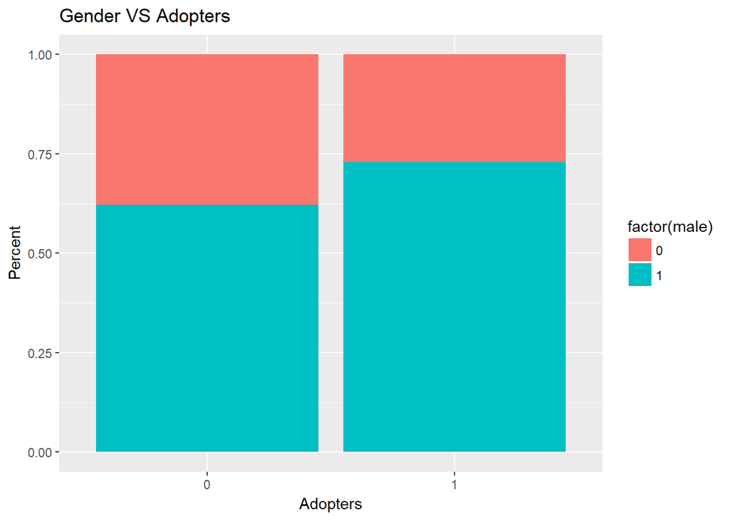

```r
library(ggplot2)
# Demorgraphic difference
#Gender VS Adopter
demo_graph<-par(mfrow=c(1,3))
ggplot(dt2,aes(x=factor(adopter),fill=factor(male)))+
  geom_bar(position="fill")+
  ggtitle("Gender VS Adopters")+xlab("Adopters")+ylab("Percent")
```

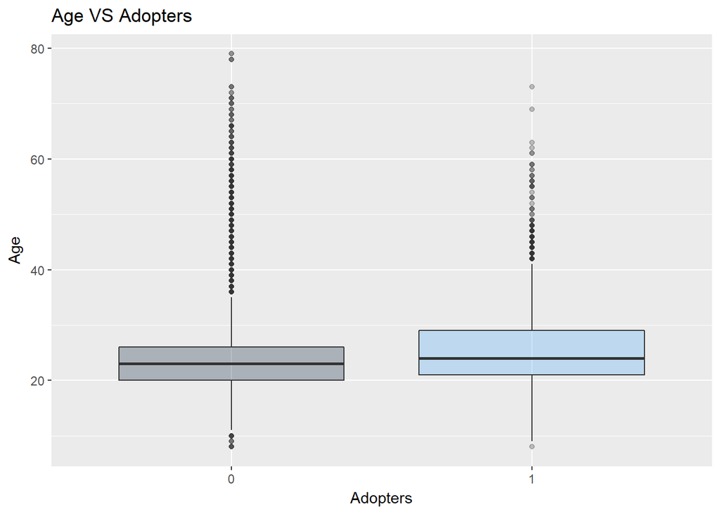

```r
#Age VS Adopter
ggplot(dt2,aes(x=factor(adopter),age,fill=adopter))+
  geom_boxplot(alpha=0.3)+
  ggtitle("Age VS Adopters")+xlab("Adopters")+ylab("Age")+
   theme(legend.position="none")
```

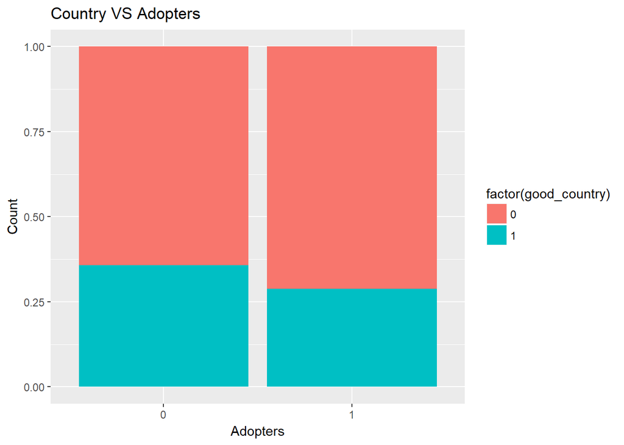

```r
#Country VS Adopter
ggplot(dt2,aes(x=factor(adopter),fill=factor(good_country)))+
  geom_bar(position="fill")+
  ggtitle("Country VS Adopters")+xlab("Adopters")+ylab("Count")
```

```r
par(demo_graph)


# As it shown on the graph below, adopters are more males, are older than non-adopters and more come from countries other than US, UK and Germany.
```

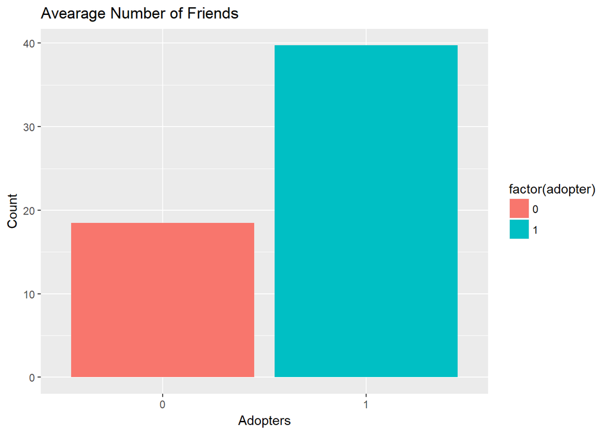

```r
#Visualize peer influence
#number of friends
peer_graph<-par(mfrow=c(1,2))

ggplot(mean_adop,aes(x=factor(adopter),friend_cnt,fill=factor(adopter)))+
  geom_bar(stat="identity")+
   ggtitle("Avearage Number of Friends")+xlab("Adopters")+ylab("Count")
```

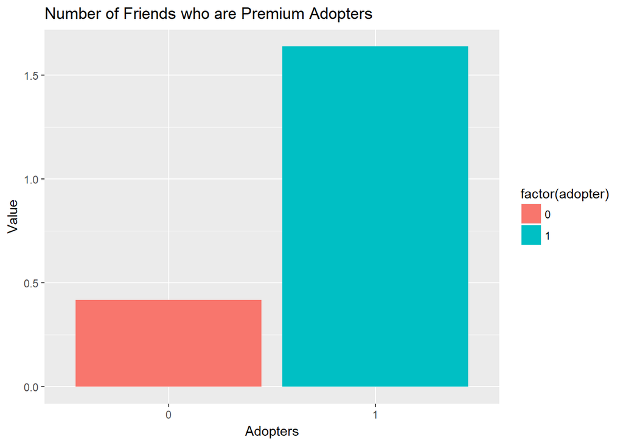

```r
#number of friends who are adopters
ggplot(mean_adop,aes(x=factor(adopter), subscriber_friend_cnt,fill=factor(adopter)))+
  geom_bar(stat="identity")+
   ggtitle("Number of Friends who are Premium Adopters")+xlab("Adopters")+ylab("Value")
```

```r
par(peer_graph)
#Adopters have more friends and they have more friends who are premium subscribers. Therefore, there might have peer influence exists.
```

# Engagement level data on activities performed when using the service, which include the number of songs the user has listened to, playlists created, “shouts” sent to friends, etc.

```r
#visualize user engagement
#number of songs listened to
par(myfrow=c(2,3))
```

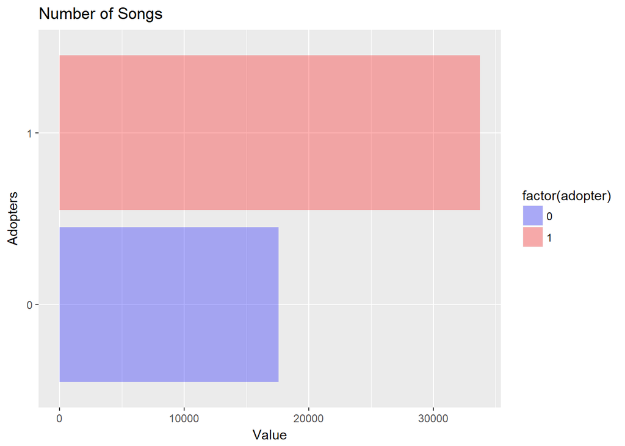

```r
ggplot(mean_adop,aes(x=factor(adopter),songsListened,fill=factor(adopter)))+
  geom_bar(stat="identity")+
  coord_flip()+
  ggtitle("Number of Songs ")+xlab("Adopters")+ylab("Value")+
  scale_fill_manual(values = alpha(c("blue", "red"), .3))
```

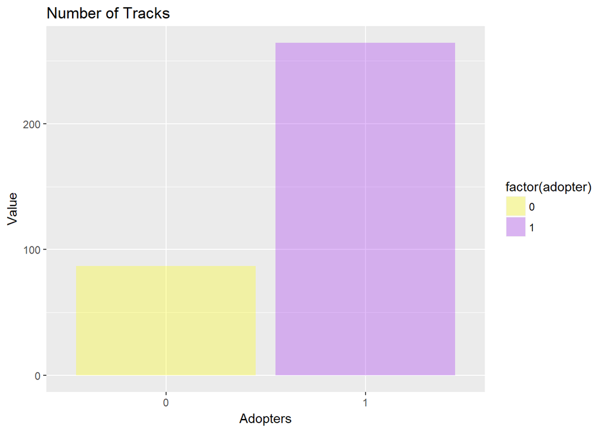

```r
#number of tracks loved
ggplot(mean_adop,aes(x=factor(adopter),lovedTracks,fill=factor(adopter)))+
  geom_bar(stat="identity")+
  ggtitle("Number of Tracks ")+xlab("Adopters")+ylab("Value")+
  scale_fill_manual(values = alpha(c("yellow", "purple"), .3))
```

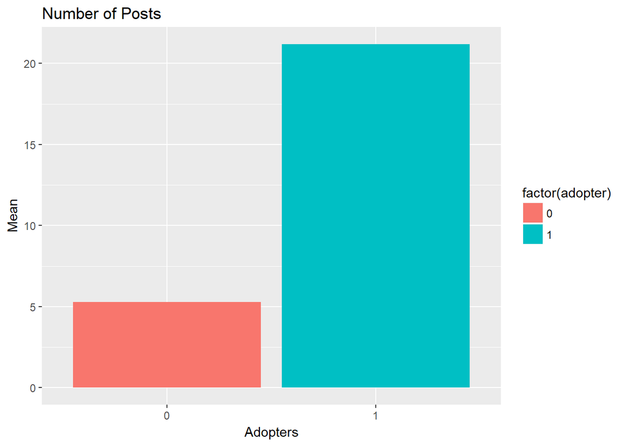

```r
#number of posts

ggplot(mean_adop,aes(x=factor(adopter), posts,fill=factor(adopter)))+
  geom_bar(stat="identity")+
   ggtitle("Number of Posts ")+xlab("Adopters")+ylab("Mean")
```

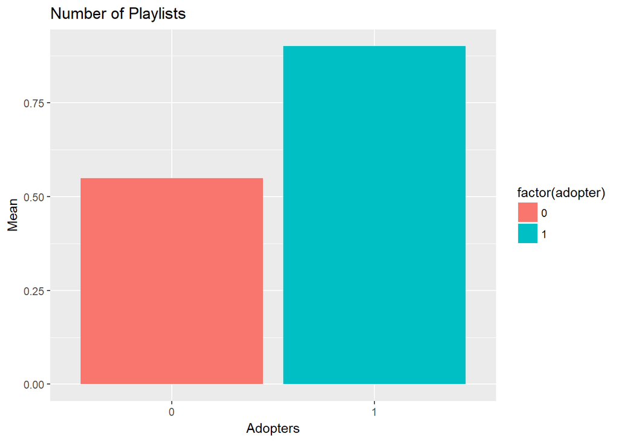

```r
#number of playlist
ggplot(mean_adop,aes(x=factor(adopter), playlists,fill=factor(adopter)))+
  geom_bar(stat="identity")+
   ggtitle("Number of Playlists ")+xlab("Adopters")+ylab("Mean")
```

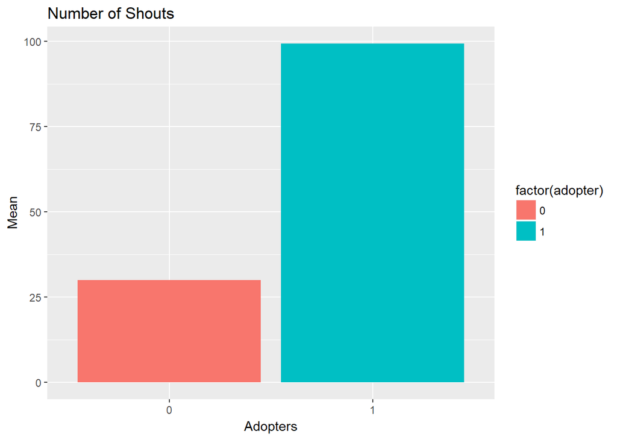

```r
#number of shouts
ggplot(mean_adop,aes(x=factor(adopter), shouts,fill=factor(adopter)))+
  geom_bar(stat="identity")+
   ggtitle("Number of Shouts ")+xlab("Adopters")+ylab("Mean")
```

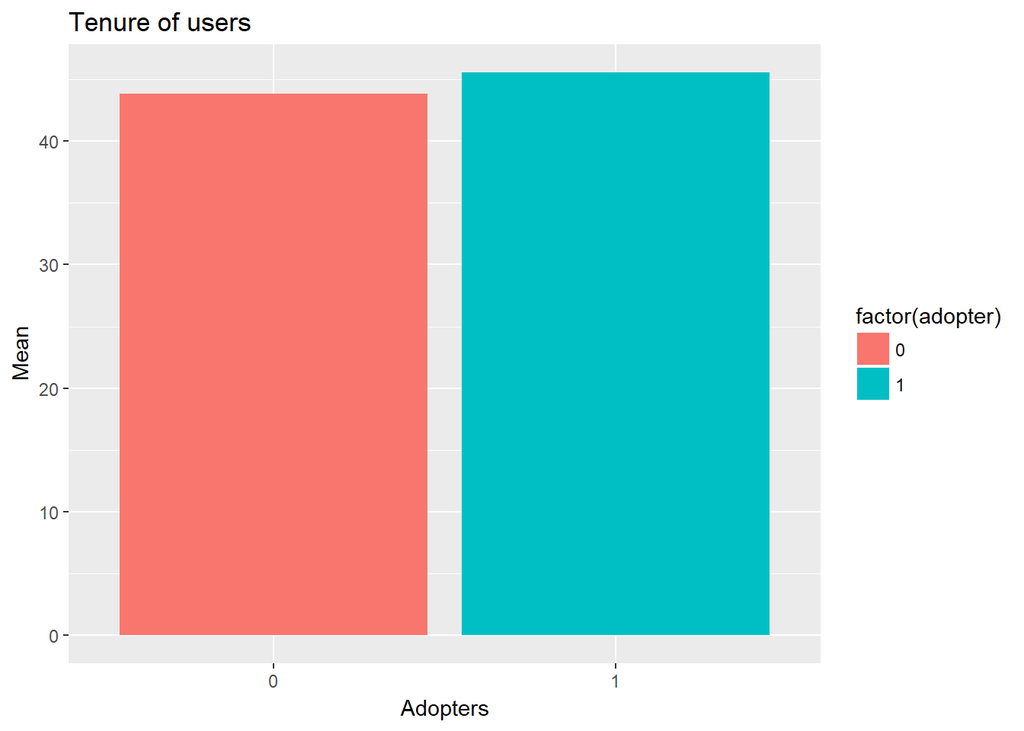

```r
#tenure
ggplot(mean_adop,aes(x=factor(adopter), tenure,fill=factor(adopter)))+
  geom_bar(stat="identity")+
   ggtitle("Tenure of users ")+xlab("Adopters")+ylab("Mean")
```

```r
#premium users on average have more songs listened, more tracks, posts, playlists,shouts than free users. Therefore, premium users might  be more engaged or more engaged users are more likely to be premium users.
```